# Where do non-cognitive skills come from?

A within-family analysis of parental inputs, social origin, and sibling personality

Garen Avanesian · Ksenia Rozhkova

November 2026

# Motivation

## The problem: which part of the family forms non-cognitive skills?

- Non-cognitive skills predict wages, schooling, and employment about as well as cognitive skills do (Heckman, Stixrud, and Urzua 2006)
- The family is where they are first formed (Cunha and Heckman 2007)
- But “the family” is a bundle. Children of one household share several things at once, and each child is still treated a little differently
- Which part does the work decides what policy can change: **resources** can be redistributed, the parents’ **own traits** cannot

What siblings share

**Their parents’ traits**, passed on through genes and by example **The household’s resources**: income, education, jobs, rules, religion **The community**: settlement, region, schools **What differs**: sex, birth order, health, and how each child is treated

## Why the answer is not yet known

Short inventories are noisy

Surveys measure the Big Five with a few items answered once. In our data **40–56%** of the variance of one score is noise, and relatives interviewed in the same visit answer more alike than their lasting traits would make them.

Noise hides the parents’ role

When the parents’ observed scores enter a model of the children’s scores, the noise weakens their link to the child. The share of sibling resemblance attributed to the parents is then **understated**, and so is their part in carrying advantage across generations.

How large is the parents’ part once the noise is removed, and do the family’s resources still matter once the parents’ own traits are held constant?

## Two frameworks behind the questions

Technology of skill formation

A child’s skills are produced over childhood from the parents’ endowments and the family’s investments. Skills formed early raise the return to later investment.

Cunha and Heckman 2007; Cunha, Heckman, and Schennach 2010

Inheritance of advantage

Non-cognitive skills are one route by which economic advantage passes between generations: children of better-off parents grow up with the traits employers reward.

Bowles, Gintis, and Osborne 2001; Bowles and Gintis 2002

Both predict a gradient of children’s traits in family resources. They differ on what happens to it once the parents’ own traits are held constant: **investment** says it remains, **transmission of what parents are** says it shrinks.

# Literature

## The closest study: Anger and Schnitzlein (2017)

What they do

- German Socio-Economic Panel (SOEP), Big Five of siblings and their parents
- Sibling correlations from a multilevel model of the siblings’ scores
- Add the parents’ observed scores and other parental characteristics; the share explained is the fall in the sibling correlation

What they find

- Sibling correlations of **0.22–0.46**
- Parents’ skills and all observed parental characteristics together account for **at most 36%** of them

Limitations we address

- **Parents’ scores enter with their noise.** A single short administration attenuates their coefficients, so the parents’ share is a lower bound
- **Same-visit answers.** Relatives interviewed together answer alike; correlating scores from one round mixes the visit with the family
- **One country.** Evidence from Germany; whether the parents’ share is similar in a society with a different family structure and recent history, such as Russia, is open

Anger, S., and D. D. Schnitzlein (2017). Cognitive skills, non-cognitive skills, and family background: evidence from sibling correlations. *Journal of Population Economics*.

## Wider evidence on family resemblance in skills and attitudes

| Study | Data | What they find | What remains open |
| --- | --- | --- | --- |
| Grönqvist, Öckert, and Vlachos (2017), *J. Human Resources* | Swedish military enlistment | The father–son correlation in non-cognitive ability rises sharply once measurement error is dealt with | Fathers and sons only; no split of sibling resemblance |
| Dohmen, Falk, Huffman, and Sunde (2012), *Rev. Econ. Studies* | SOEP, Germany | Children resemble their parents in risk and trust attitudes | Attitudes, not the Big Five; resources not set against parents’ traits |
| Collado, Ortuño-Ortín, and Stuhler (2023), *Rev. Econ. Studies* | Extended family data | Spouses resemble each other, so the two parents’ contributions overlap and must be measured jointly | How both parents’ traits jointly predict a child’s personality |
| Mazumder (2008), *J. Population Econ.*; Björklund and Jäntti (2012), *Labour Econ.* | US, Nordic registers | Sibling correlations in earnings and schooling are far larger than parents’ income or education account for | Skills, and the parents’ own traits as a predictor |
| Vukasović and Bratko (2015), *Psych. Bulletin*; Plomin and Daniels (1987), *Behav. Brain Sci.* | Twin and adoption studies | Personality is about 40% heritable, with almost no shared-environment variance in Western samples | Parents’ measured traits; non-Western settings; resources |
| Blanden, Gregg, and Macmillan (2007), *Economic J.* | British cohort data | Non-cognitive skills in childhood account for part of the persistence of income between parents and children | Russia; traits measured with their noise removed |

## What we add

1. Measurement

Every kin correlation is estimated in the **persistent trait**, from scores taken in different rounds and scaled by each person’s retest covariance. This removes both the noise and the shared visit.

2. Data

A **Russian household panel** with the Big Five for the whole adult sample in three rounds, links to parents, siblings, step-parents, and in-laws, and family records from childhood back to 1994.

3. Channels

Family resources with and without the parents’ traits (**2SLS**), parents’ education across cohorts, earnings persistence, and parenting **recorded before** the child’s traits were measured.

## Three research questions

[output not shown]

## Hypotheses (1/2): resemblance and its split

|  | Hypothesis | Test |
| --- | --- | --- |
| **H1** | Siblings, mothers and children, and fathers and children correlate positively in the persistent part of every Big Five trait | Cross-round kin correlations with 95% bootstrap intervals over families, as measured and with settlement-and-round means removed |
| **H2** | Both parents’ traits predict a positive share of sibling resemblance, and the share is **larger once the noise in the parents’ scores is removed** than with their observed scores | Share $R^2_P/\rho_{sib}$ with bootstrap intervals, on all pairs and on one set of families; the same share from a multilevel model with observed parental scores, same siblings |
| **H3** | Siblings resemble each other **beyond** what their parents’ traits predict | Remainder $\rho_{sib} - R^2_P$ and its bootstrap SE; parent–child correlations of only children against children with brothers or sisters |
| **H4** | Children whose parents had more education, high-skilled jobs, and higher earnings in their childhood score higher on the Big Five | OLS of the person’s mean score on the parents’ inputs and settlement; earnings rank linear and in quarters; top–bottom gap in SD of the persistent trait |
| **H5** | If resources act as **investments**, the gradients of H4 remain once the parents’ own score on the same trait is held constant | Same regression without (OLS) and with the parents’ trait (2SLS, one round instrumented by another); share of each gradient through the parents’ traits; earnings at ages 0–9 and 10–18 entered together |

## Hypotheses (2/2): channels and differences between siblings

|  | Hypothesis | Test |
| --- | --- | --- |
| **H6** | A parent’s degree goes with higher scores in the child, **less so in cohorts in which degrees were common** | OLS on everyone reporting the parents’ education; agreement of reports with the parents’ records; the same regression in three birth cohorts, oldest against youngest |
| **H7** | The person’s traits account for part of the **persistence of earnings** between parents and children | Fall in the rank–rank slope when traits are added, by OLS and with each trait instrumented by another round, against the fall when tertiary education is added |
| **H8** | Parents’ involvement, closeness, and religiosity go with the child’s traits, between families and between siblings; **activities recorded during childhood** predict later traits | Own reports; sibship fixed effects; the sibling’s report; the 2021 child questionnaire, also with earlier school marks held constant; father against mother |
| **H9** | Characteristics the child’s traits cannot affect (sex, birth order, disability) explain **only a small part** of the differences between siblings | Within-sibship $R^2$ on scores not adjusted for sex or age |
| **H10** | More cultural outings go with openness, more organized activities with conscientiousness | OLS of each later trait on the share of childhood questionnaires reporting an activity, one at a time, origin held constant |

# Data and samples

## RLMS-HSE: the Big Five for a whole household panel

24,928 people with a Big Five score

5,832 parent–child pairs scored in the same two rounds

1,191 sibling pairs scored in the same two rounds

- A household panel interviewed every year since 1994; kin links come from the survey’s relatives file
- **Big Five**: the 15-item BFI-S, three items per trait; the whole adult sample in **2016, 2020, and 2025**
- One administration per person and period, so **at most three scores** per person
- Family background (parents’ education, earnings, jobs, settlement) observed in childhood, 1994–2025

## The samples and kin pairs

| Subset | Scored | Same two rounds | Families | Used for |
| --- | --- | --- | --- | --- |
| **1. Everyone** |  |  |  |  |
| People | 24,928 | 15,181 | 7,532 | Noise in a score |
| People who report their parents’ education | 17,215 |  |  | Parents’ degree |
| **2. Parents and children** |  |  |  |  |
| Children with a scored mother or father | 7,694 | 4,170 | 2,641 | Parent–child resemblance (1,616 only children) |
| Mother and child (pairs) | 7,400 | 3,954 | 2,540 | Parent–child resemblance |
| Father and child (pairs) | 3,903 | 1,878 | 1,310 | Parent–child resemblance |
| Step-parent and child (pairs) | 947 | 450 | 358 | Resemblance without shared genes |
| Children with a parent observed in childhood | 5,417 |  | 3,349 | Family origin |
| and the parents scored in two other rounds | 3,414 |  | 2,093 | Family origin, parents’ traits added |
| **3. Siblings** |  |  |  |  |
| People with a scored brother or sister | 3,935 | 1,859 | 793 | Why siblings differ |
| Siblings (pairs) | 2,590 | 1,191 | 793 | Sibling resemblance and its split |
| Sibling pairs, both parents scored in the same rounds |  | 482 | 318 | The split in one set of families |
| **Other kin pairs** |  |  |  |  |
| Spouses (pairs) | 6,878 | 4,101 | 3,442 | Correlation between the parents |
| Parent-in-law and child-in-law (pairs) | 3,193 | 1,663 | 996 | Resemblance without shared genes |

Only pairs scored **in the same two rounds** enter kin correlations, which separates the persistent trait from noise. Family origin needs a parent observed in the panel during childhood, scored or not.

## Who is in the samples

**Everyone with a score**

|  | Value |
| --- | --- |
| People | 24,928 |
| Women (share) | 0.57 |
| Age at first administration, mean (SD) | 42.3 (19.3) |
| Age at first administration, 10th–90th percentile | 16.5–69.5 |
| Scored in two or more rounds | 15,181 |
| Scored in all three rounds | 8,060 |
| Administrations | 48,169 |
| Families | 7,532 |

**Family origin sample: the childhood home**

| Mean | Either parent observed | Both parents observed |
| --- | --- | --- |
| Either parent has a degree | 0.36 | 0.40 |
| Either parent high-skilled white-collar | 0.45 | 0.50 |
| Parents’ weekly hours (tens) | 3.28 | 3.38 |
| Parents’ earnings rank | 0.51 | 0.51 |
| Regional center | 0.38 | 0.36 |
| City | 0.26 | 0.26 |
| Urban-type settlement | 0.07 | 0.07 |
| Village | 0.29 | 0.31 |
| Childhood waves observed | 7.87 | 8.87 |
| People | 5,417 | 3,785 |
| Born | 1970–2013 | 1970–2013 |

Childhood: waves before the first administration in which the person was under 19 (under 25 where there is no such wave). Earnings rank: each parent ranked within the year among mothers or fathers, mean of the two.

# Measurement

## Half of one score is noise

- Chart
- Table

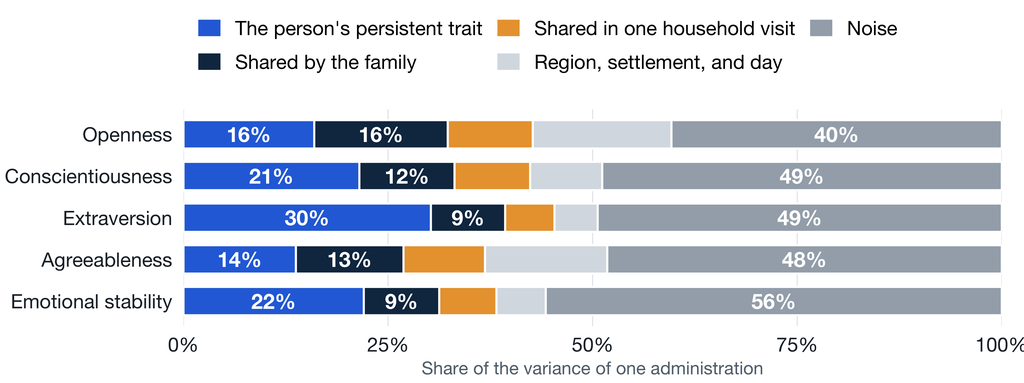

| Level | O | C | E | A | ES |
| --- | --- | --- | --- | --- | --- |
| Person | 16% | 21% | 30% | 14% | 22% |
| Family | 16% | 12% | 9% | 13% | 9% |
| Household visit | 10% | 9% | 6% | 10% | 7% |
| Region | 8% | 2% | 1% | 6% | 2% |
| Settlement within region | 7% | 6% | 3% | 6% | 3% |
| Interview day within settlement | 2% | 1% | 1% | 3% | 1% |
| Noise | 40% | 49% | 49% | 48% | 56% |
| Scores (people) | 48,169 (24,928) | 48,169 (24,928) | 48,169 (24,928) | 48,169 (24,928) | 48,169 (24,928) |

Linear multilevel model on every score of every round, with random intercepts for region, settlement, interview day, household visit, family, and person (REML). Relatives in the **same visit** share an extra 6–10%.

## Relatives interviewed together look more alike

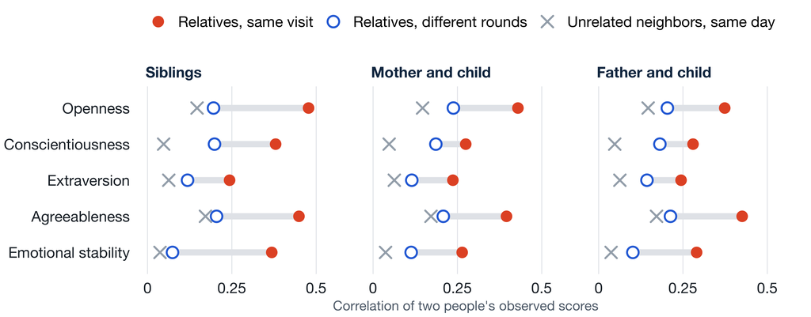

Same-visit correlations are about **twice** the cross-round ones. An estimator that multiplies two scores from the same round counts the visit as family resemblance.

## The fix: correlate relatives across rounds

Score of person $i$ in round $t$: $\;Y_{it} = \theta_i + s_{h(i)t} + e_{it}$, with persistent trait $\theta_i$, visit component $s$, and noise $e$.

$$\rho_k \;=\; \frac{\mathrm{Cov}(Y_{it},\,Y_{js})}{\sqrt{\mathrm{Cov}(Y_{it},\,Y_{is})\;\mathrm{Cov}(Y_{jt},\,Y_{js})}}, \qquad s \neq t$$

**Numerator**: one relative in round $t$ times the other in round $s$. The noise and the visit component drop out.

**Denominator**: each person’s retest covariance, which equals $\mathrm{Var}(\theta)$. This is Spearman’s correction, with retest covariances as the reliabilities.

Products are averaged over all pairs of rounds two relatives share. Inference uses 999 bootstrap draws over families, shared across kin types.

## Averaging scores does not fix it

- Chart
- Table

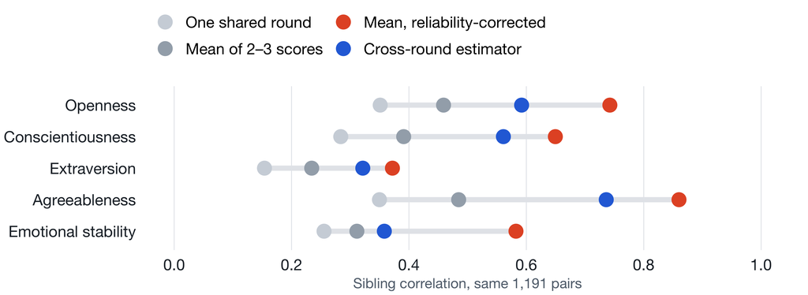

| Sibling correlation | O | C | E | A | ES |
| --- | --- | --- | --- | --- | --- |
| One shared round | 0.35 | 0.28 | 0.15 | 0.35 | 0.26 |
| Mean of 2–3 scores | 0.46 | 0.39 | 0.23 | 0.48 | 0.31 |
| Mean, reliability-corrected | 0.74 | 0.65 | 0.37 | 0.86 | 0.58 |
| **Cross-round estimator** | 0.59 | 0.56 | 0.32 | 0.74 | 0.36 |
| Reliability of the mean score | 0.62 | 0.60 | 0.63 | 0.56 | 0.53 |
| Reliability of one score (retest) | 0.39 | 0.38 | 0.41 | 0.34 | 0.31 |

Corrected means **overstate** sibling correlations by 0.05–0.22. Our rule: average when a trait is the outcome, and instrument one round by another when it is a regressor.

# Family resemblance

## Families leave a strong mark on every trait

- Chart
- Table

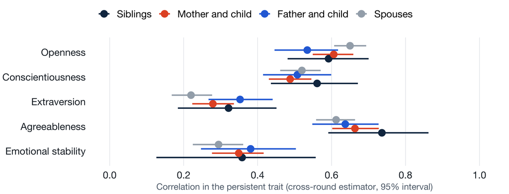

| Pair | O | C | E | A | ES | Pairs |
| --- | --- | --- | --- | --- | --- | --- |
| Siblings | 0.59 (0.05) | 0.56 (0.06) | 0.32 (0.07) | 0.74 (0.07) | 0.36 (0.11) | 1,191 |
| Mother and child | 0.61 (0.03) | 0.49 (0.03) | 0.28 (0.03) | 0.66 (0.03) | 0.35 (0.04) | 3,954 |
| Father and child | 0.53 (0.04) | 0.51 (0.05) | 0.35 (0.04) | 0.64 (0.04) | 0.38 (0.07) | 1,878 |
| Step-parent and child | 0.62 (0.09) | 0.60 (0.09) | 0.26 (0.10) | 0.72 (0.15) | 0.34 (0.14) | 450 |
| Spouses | 0.65 (0.02) | 0.52 (0.03) | 0.22 (0.03) | 0.61 (0.03) | 0.29 (0.04) | 4,101 |
| Siblings, settlement means removed | 0.48 (0.06) | 0.41 (0.07) | 0.19 (0.07) | 0.55 (0.10) | 0.33 (0.10) | 1,191 |
| Mother and child, settlement means removed | 0.51 (0.03) | 0.38 (0.03) | 0.21 (0.03) | 0.53 (0.04) | 0.30 (0.04) | 3,954 |
| Father and child, settlement means removed | 0.41 (0.05) | 0.39 (0.05) | 0.26 (0.05) | 0.45 (0.06) | 0.36 (0.07) | 1,878 |
| Step-parent and child, settlement means removed | 0.52 (0.11) | 0.48 (0.11) | 0.20 (0.11) | 0.53 (0.23) | 0.25 (0.15) | 450 |
| Spouses, settlement means removed | 0.56 (0.02) | 0.42 (0.03) | 0.14 (0.03) | 0.48 (0.03) | 0.23 (0.04) | 4,101 |

Siblings correlate at **0.32–0.74**, children and mothers at 0.28–0.66, children and fathers at 0.35–0.64. Standard errors (in the table) from 999 bootstrap draws over families.

## Splitting sibling resemblance

Two siblings share both parents. With $\rho_m$ and $\rho_f$ the child–mother and child–father correlations, and $\rho_{mf}$ the correlation between the parents, the share of a child’s trait that **both parents’ traits** predict is

$$R^2_P = \frac{\rho_m^2 + \rho_f^2 - 2\rho_m\rho_f\rho_{mf}}{1 - \rho_{mf}^2}$$

The parents’ traits alone produce a sibling correlation of $R^2_P$, so

$$\rho_{sib} \;=\; \underbrace{R^2_P}_{\color{#2a6fdb}{\text{predicted by parents' traits}}} \;+\; \underbrace{\rho_{sib} - R^2_P}_{\color{#e4572e}{\text{beyond parents' traits}}}$$

“Predicted by the parents’ traits” covers genes and example alike. The remainder includes inherited influences that the parents’ own scores do not capture.

## Parents’ traits predict 54–72% of sibling resemblance

- Chart
- Table

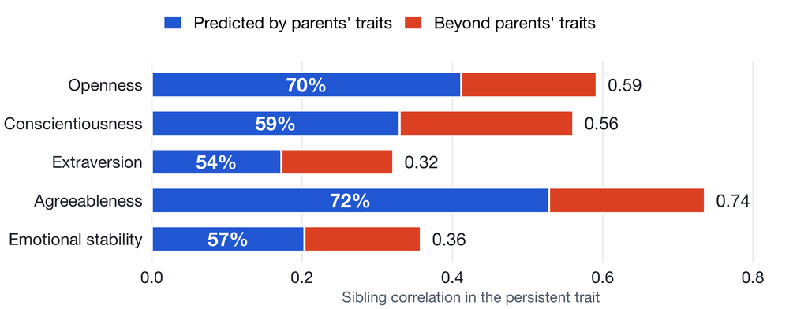

|  | O | C | E | A | ES |
| --- | --- | --- | --- | --- | --- |
| **All available pairs** |  |  |  |  |  |
| Sibling correlation (1,191 pairs) | 0.59 (0.05) | 0.56 (0.06) | 0.32 (0.07) | 0.74 (0.07) | 0.36 (0.11) |
| Predicted by both parents’ traits | 0.41 (0.04) | 0.33 (0.04) | 0.17 (0.03) | 0.53 (0.04) | 0.20 (0.04) |
| Remainder | 0.18 (0.06) | 0.23 (0.07) | 0.15 (0.07) | 0.21 (0.08) | 0.15 (0.12) |
| Parents’ share (%) | 70 | 59 | 54 | 72 | 57 |
| **Settlement means removed** |  |  |  |  |  |
| Sibling correlation (1,191 pairs) | 0.48 (0.06) | 0.41 (0.07) | 0.19 (0.07) | 0.55 (0.10) | 0.33 (0.10) |
| Predicted by both parents’ traits | 0.29 (0.03) | 0.21 (0.04) | 0.10 (0.03) | 0.34 (0.05) | 0.17 (0.04) |
| Remainder | 0.19 (0.07) | 0.19 (0.07) | 0.09 (0.07) | 0.21 (0.11) | 0.16 (0.11) |
| Parents’ share (%) | 60 | 53 | 54 | 62 | 53 |
| **One-child families left out** |  |  |  |  |  |
| Sibling correlation (1,191 pairs) | 0.59 (0.05) | 0.56 (0.06) | 0.32 (0.07) | 0.74 (0.07) | 0.36 (0.11) |
| Predicted by both parents’ traits | 0.43 (0.05) | 0.40 (0.05) | 0.18 (0.04) | 0.55 (0.06) | 0.16 (0.06) |
| Remainder | 0.16 (0.06) | 0.17 (0.07) | 0.14 (0.07) | 0.19 (0.08) | 0.19 (0.12) |
| Parents’ share (%) | 73 | 71 | 55 | 74 | 46 |
| **Same families** |  |  |  |  |  |
| Sibling correlation (482 pairs) | 0.65 (0.09) | 0.65 (0.11) | 0.31 (0.09) | 0.83 (0.09) | 0.51 (0.24) |
| Predicted by both parents’ traits | 0.57 (0.08) | 0.50 (0.10) | 0.22 (0.07) | 0.50 (0.12) | 0.12 (0.13) |
| Remainder | 0.08 (0.09) | 0.15 (0.11) | 0.08 (0.10) | 0.34 (0.13) | 0.39 (0.25) |
| Parents’ share (%) | 87 | 78 | 74 | 60 | 23 |

On all pairs the remainder is significant for four traits. In one set of families (482 sibling pairs) it is clear only for **agreeableness**: whether siblings share more than their parents’ traits predict depends on the sample.

## The standard method understates the parents’ share

- Chart
- Table

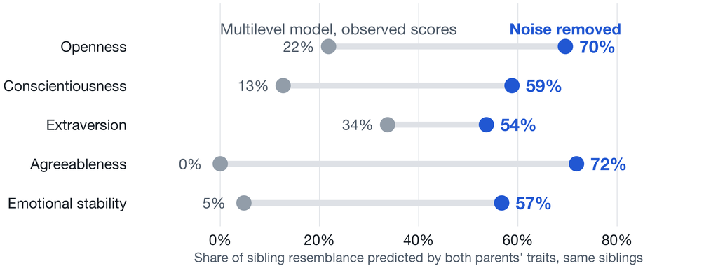

|  | O | C | E | A | ES |
| --- | --- | --- | --- | --- | --- |
| Sibling correlation, multilevel model | 0.82 | 0.77 | 0.39 | 1.00 | 0.88 |
| Parents’ share, multilevel model (%) | 22 | 13 | 34 | 0 | 5 |
| Sibling correlation, cross-round estimator | 0.59 | 0.56 | 0.32 | 0.74 | 0.36 |
| Parents’ share, cross-round estimator (%) | 70 | 59 | 54 | 72 | 57 |
| People (multilevel model) | 2,170 | 2,170 | 2,170 | 2,170 | 2,170 |
| Sibships (multilevel model) | 1,022 | 1,022 | 1,022 | 1,022 | 1,022 |

The multilevel model of Anger and Schnitzlein, with the parents’ observed scores as covariates, gives 0–34%. The noise in the parents’ scores attenuates their coefficients; removing it gives **54–72%** on the same data.

## Only children resemble their parents as much as children with siblings do

- Chart
- Table

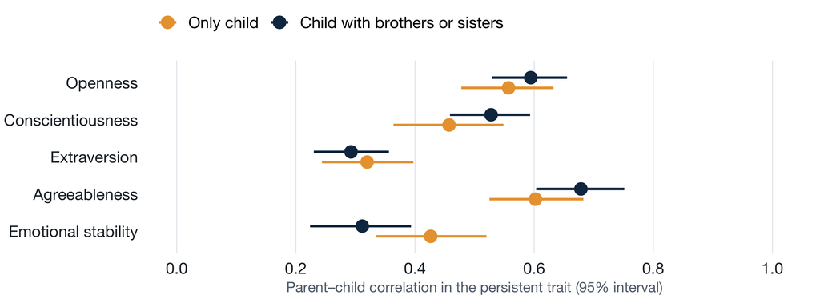

|  | O | C | E | A | ES | Pairs |
| --- | --- | --- | --- | --- | --- | --- |
| **Mother** |  |  |  |  |  |  |
| Only child | 0.58 (0.04) | 0.47 (0.05) | 0.32 (0.04) | 0.62 (0.05) | 0.41 (0.05) | 1,559 |
| Child with brothers or sisters | 0.62 (0.03) | 0.51 (0.04) | 0.25 (0.04) | 0.68 (0.04) | 0.29 (0.05) | 2,325 |
| Difference | -0.04 (0.05) | -0.04 (0.06) | 0.07 (0.06) | -0.06 (0.06) | 0.12* (0.07) |  |
| **Father** |  |  |  |  |  |  |
| Only child | 0.49 (0.08) | 0.41 (0.10) | 0.32 (0.08) | 0.55 (0.08) | 0.48 (0.10) | 544 |
| Child with brothers or sisters | 0.54 (0.05) | 0.56 (0.06) | 0.37 (0.05) | 0.67 (0.06) | 0.36 (0.09) | 1,239 |
| Difference | -0.05 (0.09) | -0.15 (0.12) | -0.05 (0.10) | -0.12 (0.10) | 0.12 (0.14) |  |
| **Parent** |  |  |  |  |  |  |
| Only child | 0.56 (0.04) | 0.46 (0.05) | 0.32 (0.04) | 0.60 (0.04) | 0.43 (0.05) | 2,103 |
| Child with brothers or sisters | 0.59 (0.03) | 0.53 (0.03) | 0.29 (0.03) | 0.68 (0.04) | 0.31 (0.05) | 3,564 |
| Difference | -0.04 (0.05) | -0.07 (0.06) | 0.03 (0.05) | -0.08 (0.05) | 0.11* (0.07) |  |

## Step-fathers resemble their step-children as much as fathers do

- Chart
- Table

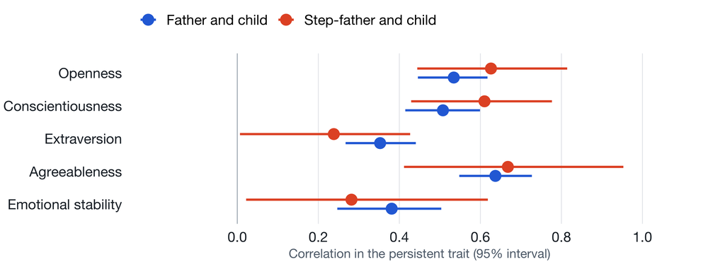

|  | O | C | E | A | ES | Pairs |
| --- | --- | --- | --- | --- | --- | --- |
| Father and child | 0.53 (0.04) | 0.51 (0.05) | 0.35 (0.04) | 0.64 (0.04) | 0.38 (0.07) | 1,878 |
| Step-father and child | 0.63 (0.09) | 0.61 (0.09) | 0.24 (0.10) | 0.67 (0.15) | 0.28 (0.15) | 382 |
| Difference | -0.09 (0.10) | -0.10 (0.10) | 0.11 (0.11) | -0.03 (0.15) | 0.10 (0.16) |  |

These pairs share no genes. A step-parent is anyone coded step-parent in at least one interview. The resemblance can come from the **household** or from **matching**: a mother may choose a partner whose personality resembles her children’s. These data cannot tell the two apart, and it needs further research.

# Social origin

## Social origin: the main question

The claim

Children of better-off parents grow up with the traits that employers reward, and so inherit part of their parents’ position (Bowles and Gintis 2002).

If true, non-cognitive skills are one route by which **inequality persists** between generations.

What we ask

1. Do children of parents with **higher earnings, a degree, a high-skilled job**, or an urban home have more favorable traits?
2. How much of each gradient remains once the **parents’ own traits** are held constant?
3. Did the link change **as degrees spread** across cohorts, and do the traits line up with **earnings persistence**?

Resources or inheritance? Investment predicts that the gradients survive the parents’ traits; passing on what parents are predicts that they shrink.

## The childhood home: four origin samples

|  | Either parent | Mother observed | Father observed | Both observed |
| --- | --- | --- | --- | --- |
| People | 5,417 | 5,297 | 3,905 | 3,785 |
| Families | 3,349 | 3,308 | 2,459 | 2,408 |
| Born from | 1,970 | 1,970 | 1,970 | 1,970 |
| Born to | 2,013 | 2,013 | 2,013 | 2,013 |
| Parents’ earnings rank (0–1) | 0.51 | 0.52 | 0.51 | 0.51 |
| Either parent has a degree | 0.36 | 0.37 | 0.39 | 0.40 |
| Mother has a degree | 0.31 | 0.31 | 0.32 | 0.32 |
| Father has a degree | 0.23 | 0.23 | 0.23 | 0.23 |
| Either parent high-skilled white-collar | 0.45 | 0.46 | 0.48 | 0.50 |
| Mother high-skilled white-collar | 0.39 | 0.40 | 0.40 | 0.41 |
| Father high-skilled white-collar | 0.23 | 0.23 | 0.23 | 0.23 |
| Parents’ weekly hours (tens) | 3.28 | 3.30 | 3.34 | 3.38 |
| Mother’s weekly hours (tens) | 3.03 | 3.03 | 2.99 | 2.99 |
| Father’s weekly hours (tens) | 3.72 | 3.76 | 3.71 | 3.76 |
| Regional center | 0.38 | 0.38 | 0.36 | 0.36 |
| City | 0.26 | 0.26 | 0.26 | 0.26 |
| Urban-type settlement | 0.07 | 0.07 | 0.07 | 0.07 |
| Village | 0.29 | 0.29 | 0.31 | 0.31 |
| Childhood waves observed | 7.87 | 7.96 | 8.71 | 8.87 |
| Settlement type changed in childhood | 0.00 | 0.00 | 0.00 | 0.00 |

Means over the panel waves before the person’s first administration under age 19 (under 25 for people without such a wave). Hours per week in tens, a wave without a job counting as zero. Earnings rank: each parent ranked within the year among mothers or fathers, mean of the parents. Each sample uses that parent’s own inputs.

## The family-origin model

$$Y_i = \alpha + \beta' R_{f(i)} + \gamma' S_{f(i)} + \delta\, \Theta_{f(i)} + \varepsilon_i$$

- $R$: parents’ **earnings rank**, **degree**, **high-skilled white-collar job**, and weekly hours in childhood
- $S$: settlement type (village as reference)
- $\Theta$: the parents’ score on the **same trait** as the outcome (mean of mother and father when both are scored)

|  | Estimator | Parents’ trait |
| --- | --- | --- |
| (1) | OLS on the mean score | not included |
| (2) | OLS, stacked rounds | not included, sample of (3) |
| (3) | **2SLS** | round $r$, instrumented by round $s$ |

Share of a gradient that runs through the parents’ traits $= (\beta_2 - \beta_3)/\beta_2$, bootstrapped over families. First-stage F: 1392–2735. Standard errors clustered by family.

## Earnings, education, occupation, and settlement in one regression

- Table
- Chart

|  | O | C | E | A | ES |
| --- | --- | --- | --- | --- | --- |
| **(1) Inputs only, OLS** |  |  |  |  |  |
| Parents’ earnings (per quarter of rank) | 0.10*** (0.02) | 0.06*** (0.02) | 0.03 (0.02) | 0.07*** (0.02) | 0.08*** (0.02) |
| Either parent has a degree | 0.14*** (0.03) | -0.00 (0.03) | -0.00 (0.03) | 0.04 (0.03) | 0.03 (0.03) |
| Either parent high-skilled white-collar | 0.04 (0.03) | 0.08*** (0.03) | -0.01 (0.03) | -0.01 (0.03) | 0.02 (0.03) |
| Parents’ weekly hours (per 10) | -0.03** (0.01) | -0.01 (0.01) | -0.01 (0.01) | -0.05*** (0.01) | -0.03** (0.01) |
| Regional center | 0.08** (0.04) | -0.13*** (0.04) | 0.09*** (0.04) | 0.01 (0.04) | -0.09*** (0.03) |
| City | -0.00 (0.04) | -0.09** (0.04) | 0.09** (0.04) | -0.15*** (0.04) | -0.07* (0.04) |
| Urban-type settlement | 0.15*** (0.05) | -0.03 (0.06) | -0.08 (0.05) | 0.10* (0.06) | 0.09 (0.05) |
| *People* | 5,417 | 5,417 | 5,417 | 5,417 | 5,417 |
| **(2) Inputs only, sample of (3), OLS** |  |  |  |  |  |
| Parents’ earnings (per quarter of rank) | 0.09*** (0.03) | 0.06* (0.03) | 0.07** (0.03) | 0.13*** (0.03) | 0.09*** (0.03) |
| Either parent has a degree | 0.13*** (0.04) | 0.05 (0.04) | -0.02 (0.04) | 0.07* (0.04) | -0.00 (0.04) |
| Either parent high-skilled white-collar | 0.07** (0.04) | 0.05 (0.04) | 0.01 (0.04) | -0.04 (0.04) | 0.04 (0.04) |
| Parents’ weekly hours (per 10) | -0.04*** (0.02) | -0.01 (0.02) | -0.04*** (0.02) | -0.09*** (0.02) | -0.04*** (0.02) |
| Regional center | 0.08** (0.04) | -0.11** (0.04) | 0.10** (0.04) | 0.03 (0.05) | -0.12*** (0.04) |
| City | -0.02 (0.05) | -0.04 (0.05) | 0.08* (0.04) | -0.07 (0.05) | -0.13*** (0.04) |
| Urban-type settlement | 0.18*** (0.06) | -0.14* (0.07) | -0.06 (0.06) | 0.16** (0.07) | -0.07 (0.07) |
| *People* | 3,414 | 3,414 | 3,414 | 3,414 | 3,414 |
| **(3) Inputs and parents’ trait, 2SLS** |  |  |  |  |  |
| Parents’ score on the same trait | 0.53*** (0.03) | 0.51*** (0.04) | 0.33*** (0.04) | 0.63*** (0.04) | 0.39*** (0.04) |
| Parents’ earnings (per quarter of rank) | -0.01 (0.02) | -0.02 (0.03) | 0.04 (0.03) | 0.03 (0.03) | 0.05** (0.02) |
| Either parent has a degree | 0.03 (0.03) | -0.01 (0.03) | -0.03 (0.04) | 0.06** (0.03) | -0.04 (0.03) |
| Either parent high-skilled white-collar | -0.03 (0.03) | 0.04 (0.04) | -0.00 (0.04) | -0.06* (0.03) | 0.02 (0.04) |
| Parents’ weekly hours (per 10) | -0.00 (0.01) | -0.01 (0.02) | -0.02 (0.02) | -0.04** (0.02) | -0.02 (0.02) |
| Regional center | 0.03 (0.04) | -0.05 (0.04) | 0.08** (0.04) | -0.00 (0.04) | -0.07** (0.04) |
| City | -0.01 (0.04) | -0.02 (0.04) | 0.07* (0.04) | -0.02 (0.04) | -0.09** (0.04) |
| Urban-type settlement | 0.04 (0.05) | -0.09 (0.06) | -0.04 (0.06) | 0.08 (0.06) | -0.00 (0.06) |
| *People* | 3,414 | 3,414 | 3,414 | 3,414 | 3,414 |

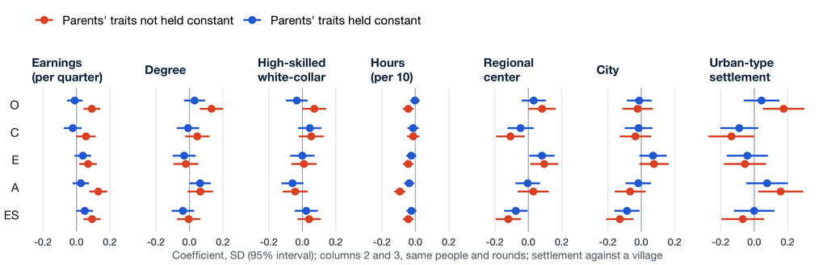

Column 1: a quarter of the parents’ earnings rank goes with 0.10 SD of openness, 0.06 of conscientiousness, 0.07 of agreeableness, and 0.08 of emotional stability. A parent with a **degree** adds 0.14 in openness; a parent in a **high-skilled white-collar job** adds 0.08 in conscientiousness. City children are less conscientious and more extraverted than village children. * p < 0.10, ** p < 0.05, *** p < 0.01.

## Children of higher earners have more favorable traits

- Chart
- Table

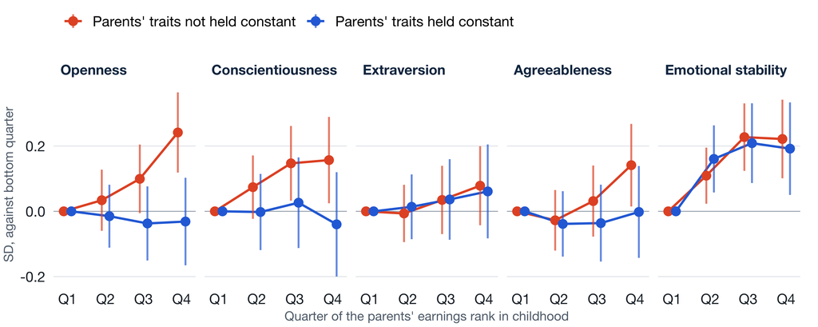

| Quarter (vs bottom) | O | C | E | A | ES |
| --- | --- | --- | --- | --- | --- |
| **(1) Inputs only, OLS** |  |  |  |  |  |
| Q2 | 0.03 (0.05) | 0.07 (0.05) | -0.01 (0.04) | -0.03 (0.05) | 0.11** (0.04) |
| Q3 | 0.10* (0.05) | 0.15** (0.06) | 0.03 (0.05) | 0.03 (0.06) | 0.23*** (0.05) |
| Q4 | 0.24*** (0.06) | 0.16** (0.07) | 0.08 (0.06) | 0.14** (0.06) | 0.22*** (0.06) |
| **(2) Inputs only, sample of (3), OLS** |  |  |  |  |  |
| Q2 | -0.04 (0.06) | 0.05 (0.07) | 0.01 (0.05) | -0.05 (0.06) | 0.14** (0.06) |
| Q3 | 0.04 (0.06) | 0.15* (0.08) | 0.08 (0.07) | 0.07 (0.07) | 0.24*** (0.07) |
| Q4 | 0.17** (0.07) | 0.14 (0.09) | 0.12 (0.08) | 0.22*** (0.08) | 0.29*** (0.08) |
| **(3) Inputs and parents’ trait, 2SLS** |  |  |  |  |  |
| Q2 | -0.01 (0.05) | -0.00 (0.06) | 0.01 (0.05) | -0.04 (0.05) | 0.16*** (0.05) |
| Q3 | -0.04 (0.06) | 0.03 (0.07) | 0.04 (0.06) | -0.04 (0.06) | 0.21*** (0.06) |
| Q4 | -0.03 (0.07) | -0.04 (0.08) | 0.06 (0.07) | -0.00 (0.07) | 0.19*** (0.07) |

## Parents’ traits account for most gradients, but not in emotional stability

- Chart
- Table

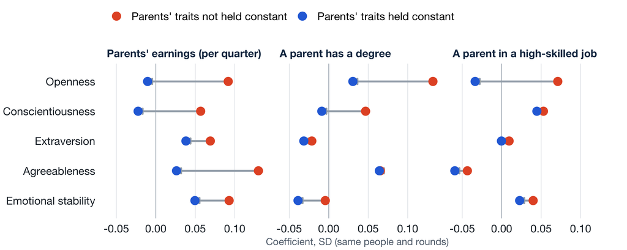

|  | O | C | E | A | ES |
| --- | --- | --- | --- | --- | --- |
| **Parents’ earnings (per quarter)** |  |  |  |  |  |
| Column 2 (OLS) | 0.09 | 0.06 | 0.07 | 0.13 | 0.09 |
| Column 3 (2SLS) | -0.01 | -0.02 | 0.04 | 0.03 | 0.05 |
| Share through parents’ traits (90% CI) | 111% (77 to 191) | 140% (66 to 376) | 45% (21 to 103) | 80% (55 to 112) | 47% (26 to 89) |
| **A parent has a degree** |  |  |  |  |  |
| Column 2 (OLS) | 0.13 | 0.05 | -0.02 | 0.07 | -0.00 |
| Column 3 (2SLS) | 0.03 | -0.01 | -0.03 | 0.06 | -0.04 |
| Share through parents’ traits (90% CI) | 77% (52 to 133) | 119% (-217 to 697) | -47% (-236 to 254) | 2% (-187 to 71) | -790% (-929 to 835) |
| **A parent in a high-skilled job** |  |  |  |  |  |
| Column 2 (OLS) | 0.07 | 0.05 | 0.01 | -0.04 | 0.04 |
| Column 3 (2SLS) | -0.03 | 0.04 | -0.00 | -0.06 | 0.02 |
| Share through parents’ traits (90% CI) | 147% (77 to 526) | 16% (-84 to 154) | 103% (-192 to 524) | -37% (-331 to 351) | 43% (-142 to 185) |
| **Earnings gradient in the persistent trait** |  |  |  |  |  |
| Per quarter, persistent-trait SD | 0.15 | 0.10 | 0.05 | 0.11 | 0.13 |
| Bottom to top quarter, persistent-trait SD | 0.44 | 0.30 | 0.15 | 0.33 | 0.40 |
| People | 3,414 | 3,414 | 3,414 | 3,414 | 3,414 |

Held against the parents’ own traits, the earnings gradient in **openness, conscientiousness, and agreeableness shrinks to about zero**; for the degree and openness 77% runs through the parents’ traits. In **extraversion and emotional stability** only 45% and 47% do, and in emotional stability children of the poorest quarter score 0.16 to 0.21 below every other quarter whatever their parents’ traits.

## Mothers’ and fathers’ inputs

- Chart
- Both parents
- Mother observed
- Father observed

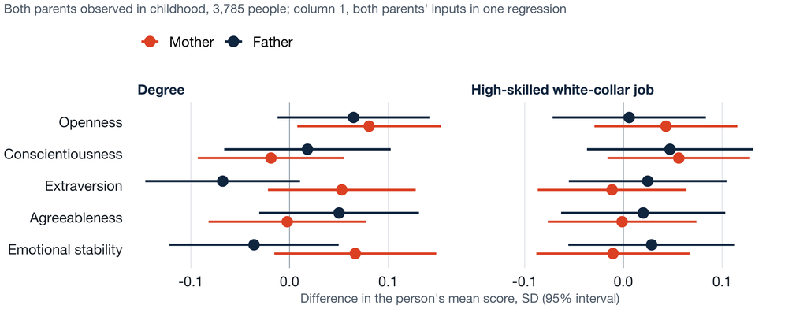

|  | O | C | E | A | ES |
| --- | --- | --- | --- | --- | --- |
| **(1) Inputs only, OLS** |  |  |  |  |  |
| Mother has a degree | 0.08** (0.04) | -0.02 (0.04) | 0.05 (0.04) | -0.00 (0.04) | 0.07 (0.04) |
| Father has a degree | 0.06* (0.04) | 0.02 (0.04) | -0.07* (0.04) | 0.05 (0.04) | -0.04 (0.04) |
| Mother high-skilled white-collar | 0.04 (0.04) | 0.06 (0.04) | -0.01 (0.04) | -0.00 (0.04) | -0.01 (0.04) |
| Father high-skilled white-collar | 0.01 (0.04) | 0.05 (0.04) | 0.02 (0.04) | 0.02 (0.04) | 0.03 (0.04) |
| Mother’s weekly hours (per 10) | -0.02 (0.01) | -0.01 (0.01) | -0.01 (0.01) | -0.04*** (0.01) | -0.03** (0.01) |
| Father’s weekly hours (per 10) | -0.02* (0.01) | -0.01 (0.01) | -0.01 (0.01) | -0.04*** (0.01) | -0.02* (0.01) |
| Parents’ earnings (per quarter) | 0.13*** (0.03) | 0.08*** (0.03) | 0.07** (0.03) | 0.09*** (0.03) | 0.11*** (0.03) |
| Regional center | 0.05 (0.04) | -0.15*** (0.04) | 0.06 (0.04) | 0.01 (0.04) | -0.11*** (0.04) |
| City | -0.05 (0.05) | -0.11** (0.05) | 0.11** (0.04) | -0.12*** (0.04) | -0.05 (0.04) |
| Urban-type settlement | 0.14** (0.06) | -0.08 (0.07) | -0.09 (0.06) | 0.10 (0.07) | 0.06 (0.06) |
| *People* | 3,785 | 3,785 | 3,785 | 3,785 | 3,785 |
| **(3) Inputs and parents’ traits, 2SLS** |  |  |  |  |  |
| Mother’s trait | 0.33*** (0.07) | 0.38*** (0.07) | 0.21*** (0.05) | 0.46*** (0.10) | 0.23*** (0.06) |
| Father’s trait | 0.31*** (0.07) | 0.29*** (0.06) | 0.25*** (0.05) | 0.31*** (0.09) | 0.37*** (0.08) |
| Mother has a degree | -0.00 (0.05) | -0.10** (0.05) | -0.00 (0.05) | -0.04 (0.05) | -0.02 (0.05) |
| Father has a degree | -0.00 (0.05) | 0.07 (0.05) | -0.07 (0.05) | 0.07 (0.05) | -0.04 (0.05) |
| Mother high-skilled white-collar | 0.02 (0.05) | 0.11** (0.05) | 0.05 (0.05) | 0.05 (0.05) | 0.02 (0.05) |
| Father high-skilled white-collar | -0.14*** (0.06) | -0.07 (0.05) | 0.04 (0.05) | -0.05 (0.05) | -0.08* (0.05) |
| Mother’s weekly hours (per 10) | 0.02 (0.02) | 0.03 (0.02) | -0.01 (0.02) | -0.01 (0.02) | -0.02 (0.02) |
| Father’s weekly hours (per 10) | 0.00 (0.01) | -0.01 (0.01) | -0.00 (0.01) | -0.02 (0.01) | -0.04** (0.01) |
| Parents’ earnings (per quarter) | -0.00 (0.04) | -0.08* (0.04) | 0.02 (0.04) | -0.01 (0.04) | 0.10** (0.04) |
| Regional center | -0.02 (0.05) | 0.01 (0.06) | 0.04 (0.05) | -0.03 (0.05) | -0.06 (0.05) |
| City | -0.05 (0.05) | -0.04 (0.06) | 0.03 (0.06) | 0.01 (0.06) | -0.02 (0.05) |
| Urban-type settlement | -0.01 (0.08) | -0.23*** (0.09) | -0.05 (0.08) | 0.14 (0.09) | -0.01 (0.09) |
| *People* | 1,749 | 1,749 | 1,749 | 1,749 | 1,749 |

|  | O | C | E | A | ES |
| --- | --- | --- | --- | --- | --- |
| **(1) Inputs only, OLS** |  |  |  |  |  |
| Mother has a degree | 0.12*** (0.03) | 0.01 (0.03) | 0.02 (0.03) | 0.05 (0.03) | 0.07** (0.03) |
| Mother high-skilled white-collar | 0.06* (0.03) | 0.08** (0.03) | -0.01 (0.03) | -0.00 (0.03) | -0.01 (0.03) |
| Mother’s weekly hours (per 10) | -0.02* (0.01) | -0.01 (0.01) | -0.00 (0.01) | -0.03** (0.01) | -0.02 (0.01) |
| Parents’ earnings (per quarter) | 0.09*** (0.02) | 0.06*** (0.02) | 0.02 (0.02) | 0.04* (0.02) | 0.07*** (0.02) |
| Regional center | 0.09** (0.04) | -0.13*** (0.04) | 0.08** (0.04) | 0.01 (0.04) | -0.10*** (0.03) |
| City | -0.00 (0.04) | -0.09** (0.04) | 0.09** (0.04) | -0.15*** (0.04) | -0.07** (0.04) |
| Urban-type settlement | 0.16*** (0.05) | -0.03 (0.06) | -0.09* (0.05) | 0.10* (0.06) | 0.08 (0.05) |
| *People* | 5,297 | 5,297 | 5,297 | 5,297 | 5,297 |
| **(3) Inputs and parents’ traits, 2SLS** |  |  |  |  |  |
| Mother’s trait | 0.49*** (0.04) | 0.49*** (0.04) | 0.28*** (0.03) | 0.63*** (0.04) | 0.32*** (0.04) |
| Mother has a degree | 0.02 (0.04) | -0.03 (0.04) | -0.02 (0.04) | 0.04 (0.04) | -0.00 (0.04) |
| Mother high-skilled white-collar | -0.02 (0.04) | 0.07* (0.04) | -0.01 (0.04) | -0.04 (0.03) | 0.01 (0.04) |
| Mother’s weekly hours (per 10) | -0.00 (0.01) | -0.00 (0.01) | -0.02 (0.01) | -0.02 (0.01) | -0.02 (0.01) |
| Parents’ earnings (per quarter) | -0.01 (0.02) | -0.05* (0.03) | 0.03 (0.02) | -0.01 (0.02) | 0.05** (0.02) |
| Regional center | 0.05 (0.04) | -0.02 (0.04) | 0.05 (0.04) | -0.01 (0.04) | -0.07* (0.04) |
| City | -0.01 (0.04) | 0.01 (0.04) | 0.06 (0.04) | -0.05 (0.04) | -0.09** (0.04) |
| Urban-type settlement | 0.06 (0.06) | -0.09 (0.06) | -0.06 (0.07) | 0.10 (0.07) | 0.00 (0.07) |
| *People* | 3,230 | 3,230 | 3,230 | 3,230 | 3,230 |

|  | O | C | E | A | ES |
| --- | --- | --- | --- | --- | --- |
| **(1) Inputs only, OLS** |  |  |  |  |  |
| Father has a degree | 0.11*** (0.04) | 0.02 (0.04) | -0.05 (0.04) | 0.06 (0.04) | -0.02 (0.04) |
| Father high-skilled white-collar | 0.03 (0.04) | 0.06 (0.04) | 0.03 (0.04) | 0.04 (0.04) | 0.05 (0.04) |
| Father’s weekly hours (per 10) | -0.02* (0.01) | -0.00 (0.01) | -0.01 (0.01) | -0.03*** (0.01) | -0.02 (0.01) |
| Parents’ earnings (per quarter) | 0.12*** (0.02) | 0.08*** (0.02) | 0.05*** (0.02) | 0.03 (0.02) | 0.08*** (0.02) |
| Regional center | 0.06 (0.04) | -0.15*** (0.04) | 0.07* (0.04) | 0.01 (0.04) | -0.10** (0.04) |
| City | -0.04 (0.04) | -0.11** (0.04) | 0.11** (0.04) | -0.12*** (0.04) | -0.05 (0.04) |
| Urban-type settlement | 0.14** (0.06) | -0.07 (0.07) | -0.09 (0.06) | 0.09 (0.06) | 0.07 (0.06) |
| *People* | 3,905 | 3,905 | 3,905 | 3,905 | 3,905 |
| **(3) Inputs and parents’ traits, 2SLS** |  |  |  |  |  |
| Father’s trait | 0.50*** (0.05) | 0.42*** (0.05) | 0.27*** (0.04) | 0.58*** (0.05) | 0.44*** (0.07) |
| Father has a degree | -0.01 (0.05) | 0.06 (0.05) | -0.07 (0.05) | 0.06 (0.05) | -0.04 (0.05) |
| Father high-skilled white-collar | -0.17*** (0.05) | -0.08 (0.05) | 0.05 (0.05) | -0.05 (0.05) | -0.07 (0.05) |
| Father’s weekly hours (per 10) | -0.01 (0.01) | -0.01 (0.01) | -0.01 (0.01) | -0.03** (0.01) | -0.04*** (0.01) |
| Parents’ earnings (per quarter) | 0.06** (0.03) | 0.03 (0.03) | 0.03 (0.03) | 0.02 (0.03) | 0.08*** (0.03) |
| Regional center | -0.02 (0.05) | -0.07 (0.05) | 0.09* (0.05) | -0.00 (0.05) | -0.10** (0.05) |
| City | -0.06 (0.06) | -0.08 (0.06) | 0.04 (0.06) | 0.03 (0.06) | -0.04 (0.05) |
| Urban-type settlement | 0.03 (0.07) | -0.23*** (0.08) | -0.05 (0.07) | 0.12 (0.08) | -0.04 (0.08) |
| *People* | 1,945 | 1,945 | 1,945 | 1,945 | 1,945 |

With both parents observed and both parents’ inputs in one regression, the **parents’ earnings** remain the strongest input (0.07–0.13 SD per quarter); the mother’s and the father’s degrees each add to **openness**. Samples with only the mother or the father observed use that parent’s own inputs and tell the same story. Column (2) omitted; standard errors clustered by family. * p < 0.10, ** p < 0.05, *** p < 0.01.

## Conscientiousness follows the earnings of adolescence

- Chart
- Table

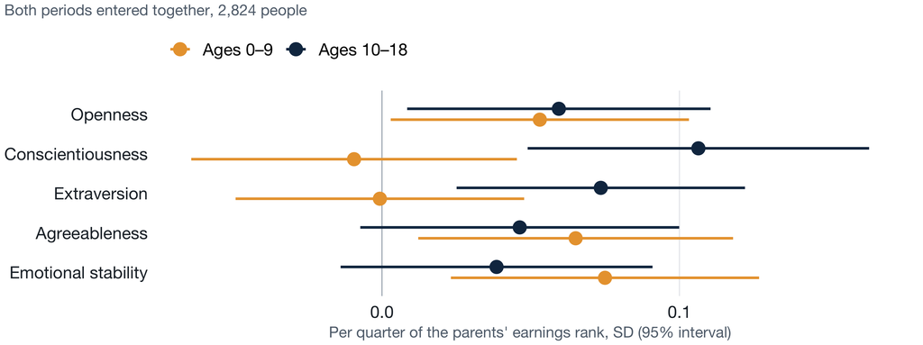

|  | O | C | E | A | ES |
| --- | --- | --- | --- | --- | --- |
| Parents’ earnings, ages 0–9 | 0.05** (0.03) | -0.01 (0.03) | -0.00 (0.02) | 0.07** (0.03) | 0.07*** (0.03) |
| Parents’ earnings, ages 10–18 | 0.06** (0.03) | 0.11*** (0.03) | 0.07*** (0.02) | 0.05* (0.03) | 0.04 (0.03) |
| Difference (0–9 minus 10–18) | -0.01 (0.04) | -0.12** (0.05) | -0.07* (0.04) | 0.02 (0.04) | 0.04 (0.04) |
| *People* | 2,824 | 2,824 | 2,824 | 2,824 | 2,824 |

The two periods’ ranks correlate at 0.73, but entered together they separate: **conscientiousness** follows ages 10–18 (0.11 against -0.01, p = 0.01 for the difference), extraversion marginally. Emotional stability and agreeableness lean to the early years, but not significantly. * p < 0.10, ** p < 0.05, *** p < 0.01.

## The gradients hold under other windows and income measures

- Chart
- Versions
- Checks

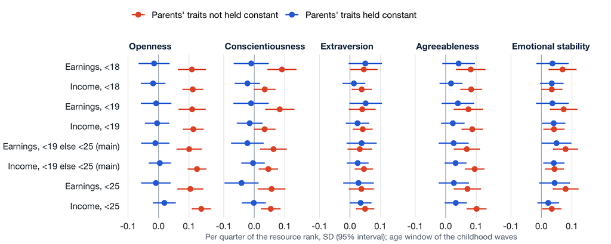

| Window | Column | O | C | E | A | ES |
| --- | --- | --- | --- | --- | --- | --- |
| **Parents’ earnings** |  |  |  |  |  |  |
| Under 18 | (1) | 0.11*** (0.02) | 0.09*** (0.02) | 0.05** (0.02) | 0.08*** (0.02) | 0.07*** (0.02) |
| Under 18 | (3) | -0.01 (0.03) | -0.01 (0.03) | 0.05* (0.03) | 0.04 (0.03) | 0.04 (0.03) |
| Under 19 | (1) | 0.11*** (0.02) | 0.08*** (0.02) | 0.04* (0.02) | 0.07*** (0.02) | 0.07*** (0.02) |
| Under 19 | (3) | -0.01 (0.03) | -0.01 (0.03) | 0.05* (0.03) | 0.04 (0.03) | 0.04 (0.03) |
| Under 19, else 25 (main) | (1) | 0.10*** (0.02) | 0.06*** (0.02) | 0.03 (0.02) | 0.07*** (0.02) | 0.08*** (0.02) |
| Under 19, else 25 (main) | (3) | -0.01 (0.02) | -0.02 (0.03) | 0.04 (0.03) | 0.03 (0.03) | 0.05** (0.02) |
| Under 25 | (1) | 0.10*** (0.02) | 0.06** (0.02) | 0.04* (0.02) | 0.07*** (0.02) | 0.08*** (0.02) |
| Under 25 | (3) | -0.01 (0.02) | -0.04 (0.03) | 0.03 (0.03) | 0.03 (0.03) | 0.04* (0.03) |
| **Household income** |  |  |  |  |  |  |
| Under 18 | (1) | 0.11*** (0.02) | 0.03* (0.02) | 0.04** (0.02) | 0.08*** (0.02) | 0.03* (0.02) |
| Under 18 | (3) | -0.02 (0.02) | -0.02 (0.02) | 0.01 (0.02) | 0.02 (0.02) | 0.03* (0.02) |
| Under 19 | (1) | 0.11*** (0.02) | 0.03* (0.02) | 0.04** (0.02) | 0.09*** (0.02) | 0.04** (0.02) |
| Under 19 | (3) | -0.00 (0.02) | -0.01 (0.02) | 0.02 (0.02) | 0.02 (0.02) | 0.04** (0.02) |
| Under 19, else 25 (main) | (1) | 0.13*** (0.02) | 0.05*** (0.02) | 0.05*** (0.02) | 0.10*** (0.02) | 0.04*** (0.02) |
| Under 19, else 25 (main) | (3) | 0.00 (0.02) | -0.00 (0.02) | 0.03 (0.02) | 0.03* (0.02) | 0.04** (0.02) |
| Under 25 | (1) | 0.14*** (0.02) | 0.05*** (0.02) | 0.05*** (0.02) | 0.10*** (0.02) | 0.03** (0.02) |
| Under 25 | (3) | 0.02 (0.02) | -0.00 (0.02) | 0.03* (0.02) | 0.03* (0.02) | 0.02 (0.02) |

|  | O | C | E | A | ES |
| --- | --- | --- | --- | --- | --- |
| **People entering through the under-25 window left out** |  |  |  |  |  |
| Parents’ earnings (per quarter of rank) | 0.11*** (0.02) | 0.08*** (0.02) | 0.04* (0.02) | 0.07*** (0.02) | 0.07*** (0.02) |
| Either parent has a degree | 0.13*** (0.03) | -0.01 (0.03) | -0.00 (0.03) | 0.03 (0.03) | 0.02 (0.03) |
| Either parent high-skilled white-collar | 0.05 (0.03) | 0.08** (0.03) | -0.01 (0.03) | 0.01 (0.03) | 0.03 (0.04) |
| Parents’ weekly hours (per 10) | -0.04*** (0.01) | -0.03** (0.01) | -0.01 (0.01) | -0.05*** (0.01) | -0.03** (0.01) |
| Regional center | 0.07* (0.04) | -0.15*** (0.04) | 0.09** (0.04) | 0.02 (0.04) | -0.08** (0.04) |
| City | -0.03 (0.04) | -0.12*** (0.04) | 0.10** (0.04) | -0.14*** (0.04) | -0.06* (0.04) |
| *People* | 4,673 | 4,673 | 4,673 | 4,673 | 4,673 |
| **Settlement type unchanged in childhood** |  |  |  |  |  |
| Parents’ earnings (per quarter of rank) | 0.10*** (0.02) | 0.06*** (0.02) | 0.03 (0.02) | 0.07*** (0.02) | 0.08*** (0.02) |
| Either parent has a degree | 0.14*** (0.03) | -0.00 (0.03) | -0.00 (0.03) | 0.04 (0.03) | 0.03 (0.03) |
| Either parent high-skilled white-collar | 0.04 (0.03) | 0.08*** (0.03) | -0.01 (0.03) | -0.01 (0.03) | 0.02 (0.03) |
| Parents’ weekly hours (per 10) | -0.03** (0.01) | -0.01 (0.01) | -0.01 (0.01) | -0.05*** (0.01) | -0.03** (0.01) |
| Regional center | 0.08** (0.04) | -0.13*** (0.04) | 0.09*** (0.04) | 0.01 (0.04) | -0.09*** (0.03) |
| City | -0.00 (0.04) | -0.09** (0.04) | 0.09** (0.04) | -0.15*** (0.04) | -0.07* (0.04) |
| *People* | 5,417 | 5,417 | 5,417 | 5,417 | 5,417 |
| **Conflicting step codings left out** |  |  |  |  |  |
| Parents’ earnings (per quarter of rank) | 0.10*** (0.02) | 0.07*** (0.02) | 0.03 (0.02) | 0.06*** (0.02) | 0.08*** (0.02) |
| Either parent has a degree | 0.14*** (0.03) | -0.01 (0.03) | -0.00 (0.03) | 0.04 (0.03) | 0.04 (0.03) |
| Either parent high-skilled white-collar | 0.04 (0.03) | 0.07** (0.03) | 0.00 (0.03) | -0.01 (0.03) | 0.01 (0.03) |
| Parents’ weekly hours (per 10) | -0.03** (0.01) | -0.01 (0.01) | -0.01 (0.01) | -0.05*** (0.01) | -0.03** (0.01) |
| Regional center | 0.08** (0.04) | -0.13*** (0.04) | 0.09** (0.04) | 0.02 (0.04) | -0.11*** (0.03) |
| City | -0.01 (0.04) | -0.10** (0.04) | 0.07* (0.04) | -0.15*** (0.04) | -0.07* (0.04) |
| *People* | 5,079 | 5,079 | 5,079 | 5,079 | 5,079 |
| **Family size and sibling sex composition** |  |  |  |  |  |
| Parents’ earnings (per quarter of rank) | 0.09*** (0.03) | 0.08*** (0.03) | 0.02 (0.03) | 0.07** (0.03) | 0.08*** (0.03) |
| Either parent has a degree | 0.16*** (0.04) | 0.00 (0.04) | -0.01 (0.04) | 0.05 (0.04) | 0.03 (0.04) |
| Either parent high-skilled white-collar | 0.03 (0.04) | 0.11*** (0.04) | 0.01 (0.04) | 0.00 (0.04) | 0.06 (0.04) |
| Parents’ weekly hours (per 10) | -0.02 (0.02) | -0.02 (0.02) | -0.00 (0.02) | -0.06*** (0.02) | -0.03* (0.02) |
| Regional center | 0.05 (0.04) | -0.13*** (0.04) | 0.11*** (0.04) | -0.01 (0.05) | -0.08** (0.04) |
| City | -0.03 (0.05) | -0.09** (0.05) | 0.12*** (0.04) | -0.17*** (0.05) | -0.04 (0.04) |
| *People* | 3,840 | 3,840 | 3,840 | 3,840 | 3,840 |

In every version the gradients without the parents’ traits are about **a tenth of an SD per quarter**; with them, openness, conscientiousness, and agreeableness shrink to about zero while **emotional stability keeps a small gradient**. Leaving out late entrants, movers, or conflicting step codings, or adding family size and sibling sex composition, changes none of this.

## Parents’ education as reported: a sample of 17,215 people

- Chart
- Agreement with the parents’ own record

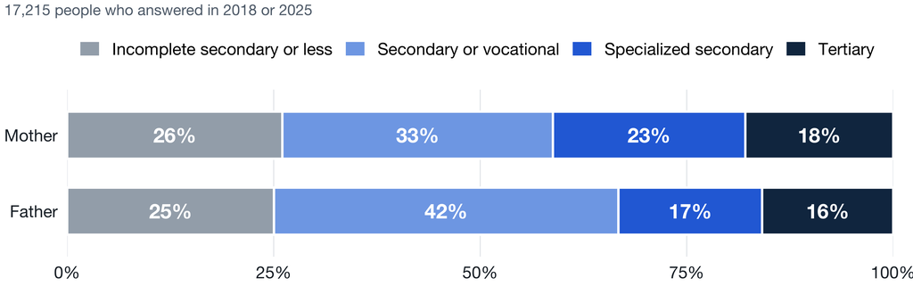

| Comparison | People | Degree, first source | Degree, second source | Agreement | Cohen’s κ |
| --- | --- | --- | --- | --- | --- |
| Mother: report vs own record in childhood | 3,814 | 31% | 31% | 96% | 0.91 |
| Father: report vs own record in childhood | 3,053 | 24% | 23% | 95% | 0.85 |
| Mother: report of 2018 vs 2025 | 7,170 | 16% | 16% | 94% | 0.78 |
| Father: report of 2018 vs 2025 | 6,882 | 16% | 15% | 94% | 0.75 |

The linked origin sample needs parents interviewed in the panel; the report needs only the person. **17,215** people report, against 2,997 with linked parents. The report agrees with the parent’s own record on the degree in 96% of cases for mothers (κ = 0.91) and 95% for fathers (κ = 0.85).

## Each step of parents’ education adds to the child’s traits

- Chart
- Table

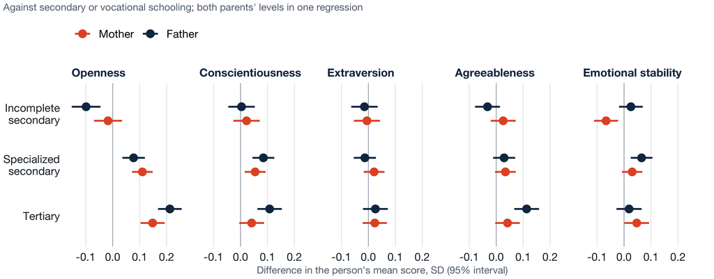

|  | O | C | E | A | ES |
| --- | --- | --- | --- | --- | --- |
| **Mother’s education** |  |  |  |  |  |
| Incomplete secondary or less | -0.02 (0.03) | 0.02 (0.02) | -0.01 (0.02) | 0.03 (0.02) | -0.07*** (0.02) |
| Specialized secondary | 0.11*** (0.02) | 0.05*** (0.02) | 0.02 (0.02) | 0.03* (0.02) | 0.03 (0.02) |
| Tertiary | 0.15*** (0.02) | 0.04* (0.02) | 0.02 (0.02) | 0.04* (0.02) | 0.05** (0.02) |
| **Father’s education** |  |  |  |  |  |
| Incomplete secondary or less | -0.10*** (0.03) | 0.00 (0.03) | -0.01 (0.02) | -0.03 (0.02) | 0.03 (0.02) |
| Specialized secondary | 0.08*** (0.02) | 0.08*** (0.02) | -0.01 (0.02) | 0.03 (0.02) | 0.07*** (0.02) |
| Tertiary | 0.21*** (0.02) | 0.11*** (0.02) | 0.03 (0.02) | 0.11*** (0.02) | 0.02 (0.02) |
| *People* | 17,215 | 17,215 | 17,215 | 17,215 | 17,215 |

The gradient rises step by step: a **specialized secondary** degree (technikum) already adds to openness and conscientiousness compared with secondary or vocational schooling, and a degree adds more to openness. OLS; standard errors clustered by family. * p < 0.10, ** p < 0.05, *** p < 0.01.

## A father’s degree: openness, conscientiousness, and agreeableness

- Chart
- Three samples

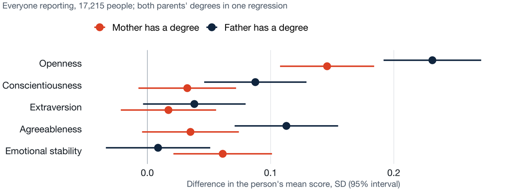

|  | O | C | E | A | ES |
| --- | --- | --- | --- | --- | --- |
| **Everyone reporting** |  |  |  |  |  |
| Mother has a degree | 0.15*** (0.02) | 0.03 (0.02) | 0.02 (0.02) | 0.03* (0.02) | 0.06*** (0.02) |
| Father has a degree | 0.23*** (0.02) | 0.09*** (0.02) | 0.04* (0.02) | 0.11*** (0.02) | 0.01 (0.02) |
| Father has a degree, persistent-trait SD | 0.34 | 0.14 | 0.06 | 0.18 | 0.01 |
| *People* | 17,215 | 17,215 | 17,215 | 17,215 | 17,215 |
| **Linked parents, reported degree** |  |  |  |  |  |
| Mother has a degree | 0.17*** (0.04) | 0.06 (0.04) | 0.05 (0.04) | 0.01 (0.04) | 0.07* (0.04) |
| Father has a degree | 0.16*** (0.04) | 0.11*** (0.04) | 0.01 (0.04) | 0.12*** (0.04) | 0.03 (0.04) |
| Father has a degree, persistent-trait SD | 0.23 | 0.17 | 0.01 | 0.20 | 0.05 |
| *People* | 2,997 | 2,997 | 2,997 | 2,997 | 2,997 |
| **Linked parents, recorded degree** |  |  |  |  |  |
| Mother has a degree | 0.17*** (0.04) | 0.07* (0.04) | 0.07** (0.04) | 0.01 (0.04) | 0.09** (0.04) |
| Father has a degree | 0.13*** (0.04) | 0.07* (0.04) | -0.03 (0.04) | 0.11*** (0.04) | -0.00 (0.04) |
| Father has a degree, persistent-trait SD | 0.18 | 0.11 | -0.04 | 0.18 | -0.00 |
| *People* | 2,997 | 2,997 | 2,997 | 2,997 | 2,997 |

A father with a degree goes with 0.23 SD more openness, 0.09 more conscientiousness, and 0.11 more agreeableness; a mother with a degree with 0.15 more openness and 0.06 more emotional stability. On people with both parents on record, the **reported and recorded degrees give the same gradients**.

## Parents’ degrees mattered more when they were rare

- Chart
- Who had a degree
- Table

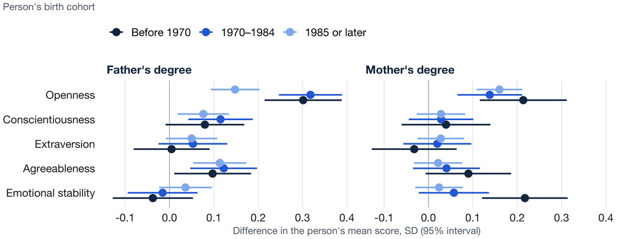

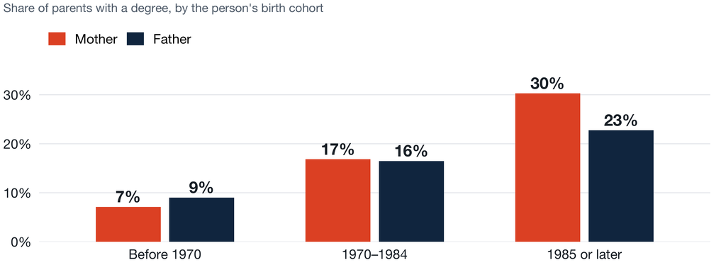

| Birth cohort | O | C | E | A | ES | With a degree | People |
| --- | --- | --- | --- | --- | --- | --- | --- |
| **Father’s degree** |  |  |  |  |  |  |  |
| Before 1970 | 0.30*** (0.04) | 0.08* (0.05) | 0.00 (0.04) | 0.10** (0.04) | -0.04 (0.05) | 9% | 6,517 |
| 1970–1984 | 0.32*** (0.04) | 0.11*** (0.04) | 0.05 (0.04) | 0.12*** (0.04) | -0.02 (0.04) | 16% | 4,624 |
| 1985 or later | 0.15*** (0.03) | 0.08** (0.03) | 0.05* (0.03) | 0.11*** (0.03) | 0.04 (0.03) | 23% | 6,074 |
| 1985 or later minus before 1970 | -0.15*** (0.05) | -0.00 (0.05) | 0.05 (0.05) | 0.02 (0.05) | 0.07 (0.05) |  |  |
| **Mother’s degree** |  |  |  |  |  |  |  |
| Before 1970 | 0.21*** (0.05) | 0.04 (0.05) | -0.03 (0.05) | 0.09* (0.05) | 0.22*** (0.05) | 7% | 6,517 |
| 1970–1984 | 0.14*** (0.04) | 0.03 (0.04) | 0.02 (0.04) | 0.04 (0.04) | 0.06 (0.04) | 17% | 4,624 |
| 1985 or later | 0.16*** (0.03) | 0.03 (0.03) | 0.03 (0.03) | 0.02 (0.03) | 0.02 (0.03) | 30% | 6,074 |
| 1985 or later minus before 1970 | -0.05 (0.06) | -0.01 (0.06) | 0.06 (0.06) | -0.07 (0.06) | -0.19*** (0.06) |  |  |

Fathers with a degree rose from 9% to 23%, mothers from 7% to 30%. As degrees spread, the father’s degree lost its link to **openness** (0.30 → 0.15, p = 0.003) and the mother’s to **emotional stability** (0.22 → 0.02); the father’s link to **conscientiousness and agreeableness holds in every cohort**.

## Traits account for as much earnings persistence as education

- Table
- Chart

| Specification | Rank–rank slope (SE) | Share accounted for (95% CI) | Observations |
| --- | --- | --- | --- |
| **Mean score, OLS** |  |  |  |
| Parents’ earnings rank only | 0.27*** (0.02) |  | 2,240 |
| + own traits | 0.25*** (0.02) | 9% (4–13) | 2,240 |
| + own tertiary degree | 0.24*** (0.02) | 11% (7–15) | 2,240 |
| + traits and degree | 0.23*** (0.02) | 16% (11–21) | 2,240 |
| **Noise removed, 2SLS** |  |  |  |
| Parents’ earnings rank only | 0.27*** (0.02) |  | 7,854 |
| + own traits, instrumented | 0.23*** (0.02) | 14% (6–24) | 7,854 |

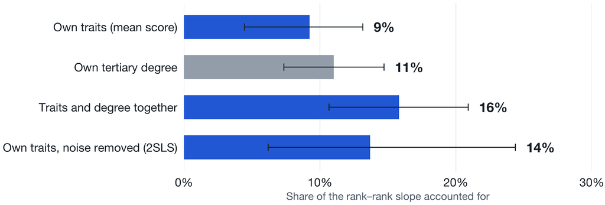

## Social origin: what we learn

1. Children of parents with **higher earnings, a degree, and a high-skilled job** have more favorable traits: 0.30–0.44 SD from the bottom to the top quarter of earnings.
2. In **openness, conscientiousness, and agreeableness** the parents’ own traits account for most of the gradient: these regressions cannot tell inherited traits from traits shaped by the parents’ resources.
3. In **emotional stability** the gap at the bottom survives the parents’ traits: children of the poorest quarter fall behind whatever their parents are like.
4. A parent’s **degree mattered most when degrees were rare**; the father’s link to conscientiousness and agreeableness did not weaken.
5. The person’s traits line up with **as much earnings persistence as education** does.

# What parents do

## Four designs for parenting, from weakest to strongest

| Design | Measure | What it rules out |
| --- | --- | --- |
| All respondents | own recollection of involvement and closeness | nothing: memory is colored by one’s own traits |
| Within sibships | own recollection, sibship fixed effects | family-level confounders |
| Sibling’s report | the sibling’s recollection | the respondent’s own memory |
| **Child questionnaire, 2021** | activities recorded at the time by an adult | recall altogether, and it precedes the trait |

OLS on the person’s mean score, with the mother’s and the father’s measure in one regression; standard errors clustered by family, or by sibship with fixed effects. Own recollections load on traits measured **before** the recall question, so the first design is not used for inference.

## What fathers do counts for conscientiousness

- Chart
- Table

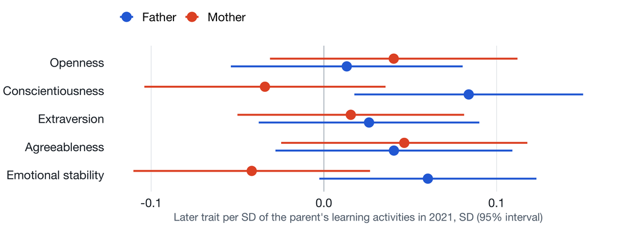

|  | O | C | E | A | ES |
| --- | --- | --- | --- | --- | --- |
| Father’s learning activities | 0.01 (0.03) | 0.08** (0.03) | 0.03 (0.03) | 0.04 (0.03) | 0.06* (0.03) |
| Mother’s learning activities | 0.04 (0.04) | -0.03 (0.04) | 0.02 (0.03) | 0.05 (0.04) | -0.04 (0.03) |
| Children | 743 | 743 | 743 | 743 | 743 |

Reading, homework, extra subjects, and school meetings, recorded by an adult in the 2021 child questionnaire **before** the trait was measured. Father: **0.08** SD of conscientiousness ($p$ = 0.013), also with earlier school marks held constant. The mother’s activities show no such link.

## Siblings differ mostly for reasons we cannot observe

≤ 7% of the variance between siblings explained by sex, birth order, and disability together

**Model**: OLS with sibship fixed effects on the person’s mean score; the share is the within-sibship $R^2$.

- Sex alone: 1–4%
- Birth order: no effect, except that eldest siblings are slightly less extraverted (-0.05, $p$ < 0.10)
- Observed family characteristics (origin, parenting, religiosity, and composition) account for 0.07–0.26 of sibling correlations of 0.36–0.85

# Conclusions

## The results survive the obvious checks

- **Round pairs**: 2016–2020, 2020–2025, and 2016–2025 agree
- **Estimator**: every pair with two different rounds
- **Response style** removed from every score
- **Community**: settlement-and-round means removed
- **Only children** and **same families** for the split
- **Step-parent coding**: counting parents with conflicting codes as biological changes no share by more than 2 points
- **Family origin**: under-18, under-19, and under-25 windows; household income; mothers, fathers, both

## What the data say about each hypothesis

|  | Hypothesis | Result |
| --- | --- | --- |
| **H1** | Positive kin correlations | Supported: siblings 0.32–0.74, mothers 0.28–0.66, fathers 0.35–0.64 |
| **H2** | Parents’ share larger with noise removed | Supported: 54–72% against 0–34% on the same siblings |
| **H3** | Resemblance beyond parents’ traits | Partly: on all pairs for four traits; in one set of families only for agreeableness |
| **H4** | Gradients in family resources | Supported: 0.30–0.44 SD top–bottom in four traits; not extraversion |
| **H5** | Gradients remain with parents’ traits held constant | Not for O, C, A: the parents’ traits account for most of them. Yes for emotional stability |
| **H6** | Degrees matter less when common | Supported for openness and emotional stability; the father’s degree keeps its link to C and A in every cohort |
| **H7** | Traits account for earnings persistence | Supported: 9–14%, about as much as education (11%) |
| **H8** | Parenting and later traits | Partly: the father’s learning activities, recorded in 2021, predict conscientiousness; the mother’s do not |
| **H9** | Small role of sex, birth order, disability | Supported: at most 7% of the variance between siblings |
| **H10** | Outings → openness, organized activities → conscientiousness | Associations only: interests and local access shape participation (backup) |

## What we learn

1. One administration of a short inventory is **half noise**. Cross-round covariances remove the noise, and the visit effect with it.
2. Parents’ traits predict **54–72%** of sibling resemblance, not the 0–34% the multilevel method gives on the same data.
3. Social origin shows up in children’s traits. For openness, conscientiousness, and agreeableness it runs **through the parents’ own traits**; for emotional stability it does not.
4. Traits account for about as much of **earnings persistence** as education does.
5. **Fathers’ learning activities** predict conscientiousness. Most of what makes siblings differ is not observed.

## Thank you

Garen Avanesian · Ksenia Rozhkova

Data: “Russia Longitudinal Monitoring survey, RLMS HSE”, conducted by National Research University “Higher School of Economics” and OOO “Demoscope” together with the Institute of Sociology of the Federal Center of Theoretical and Applied Sociology of the Russian Academy of Sciences. (RLMS HSE web site: https://www.hse.ru/rlms)

# Backup

## Backup: kin correlations by pair of rounds

| Pair and rounds | O | C | E | A | ES | Pairs |
| --- | --- | --- | --- | --- | --- | --- |
| Siblings, 2016–2020 | 0.60 (0.07) | 0.56 (0.07) | 0.33 (0.08) | 0.64 (0.08) | 0.35 (0.11) | 935 |
| Siblings, 2020–2025 | 0.63 (0.08) | 0.65 (0.10) | 0.41 (0.09) | 1.01 (0.15) | 0.06 (2.26) | 664 |
| Siblings, 2016–2025 | 0.60 (0.12) | 0.67 (0.11) | 0.23 (0.12) | 0.78 (0.13) | 0.25 (0.66) | 514 |
| Mother and child, 2016–2020 | 0.61 (0.03) | 0.47 (0.03) | 0.28 (0.03) | 0.66 (0.04) | 0.35 (0.04) | 3,130 |
| Mother and child, 2020–2025 | 0.57 (0.04) | 0.54 (0.04) | 0.31 (0.04) | 0.69 (0.04) | 0.42 (0.05) | 2,305 |
| Mother and child, 2016–2025 | 0.57 (0.05) | 0.54 (0.06) | 0.26 (0.05) | 0.66 (0.07) | 0.39 (0.08) | 1,779 |
| Father and child, 2016–2020 | 0.53 (0.05) | 0.46 (0.06) | 0.29 (0.05) | 0.65 (0.05) | 0.46 (0.07) | 1,493 |
| Father and child, 2020–2025 | 0.53 (0.06) | 0.53 (0.06) | 0.40 (0.06) | 0.62 (0.06) | 0.38 (0.09) | 1,030 |
| Father and child, 2016–2025 | 0.58 (0.09) | 0.54 (0.11) | 0.49 (0.09) | 0.74 (0.09) | 0.25 (0.18) | 789 |
| Spouses, 2016–2020 | 0.64 (0.03) | 0.51 (0.03) | 0.16 (0.03) | 0.60 (0.03) | 0.27 (0.04) | 3,342 |
| Spouses, 2020–2025 | 0.67 (0.03) | 0.59 (0.03) | 0.32 (0.04) | 0.68 (0.03) | 0.34 (0.04) | 2,599 |
| Spouses, 2016–2025 | 0.60 (0.04) | 0.52 (0.05) | 0.19 (0.05) | 0.63 (0.05) | 0.35 (0.06) | 2,146 |

## Backup: paper figure, family origin with and without the parents’ traits

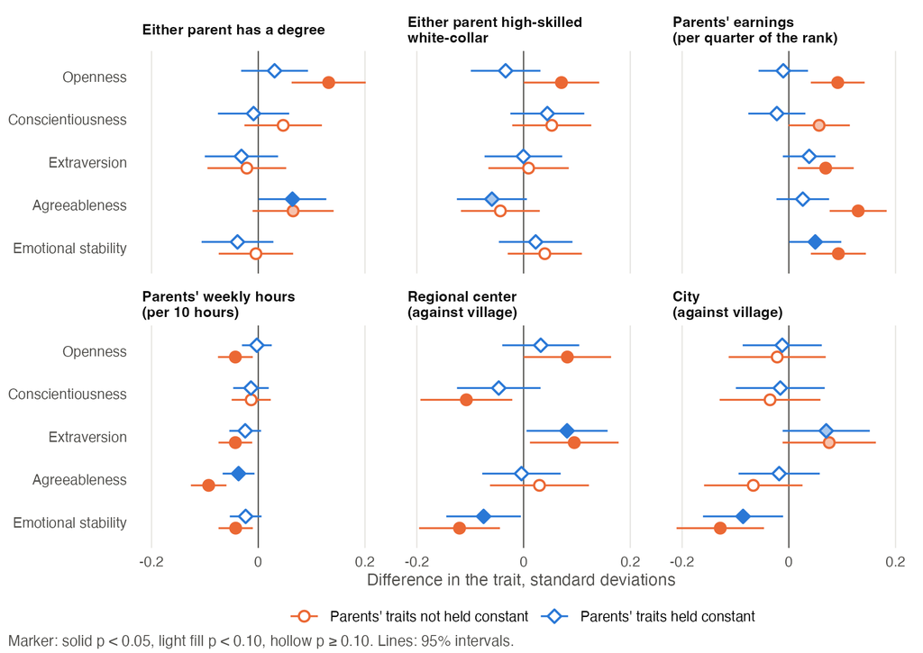

## Backup: paper figure, the earnings gradient and the share via parents

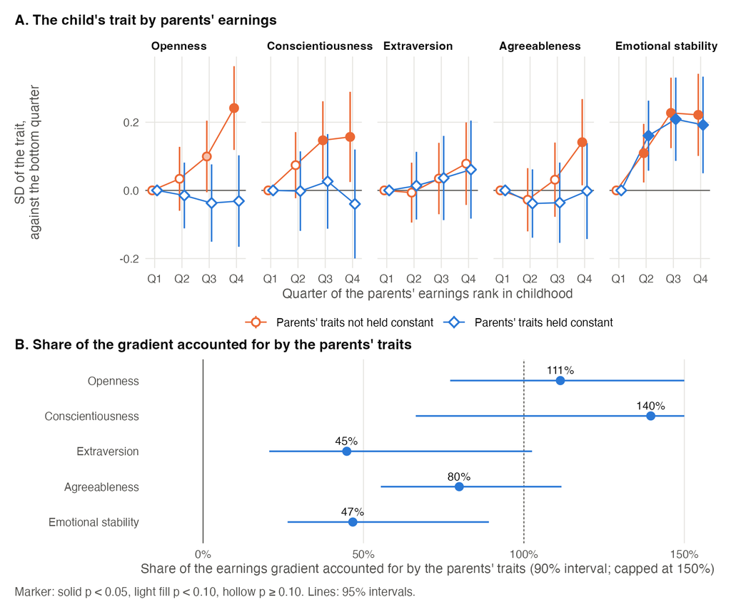

## Backup: paper figure, parents’ reported education and cohorts

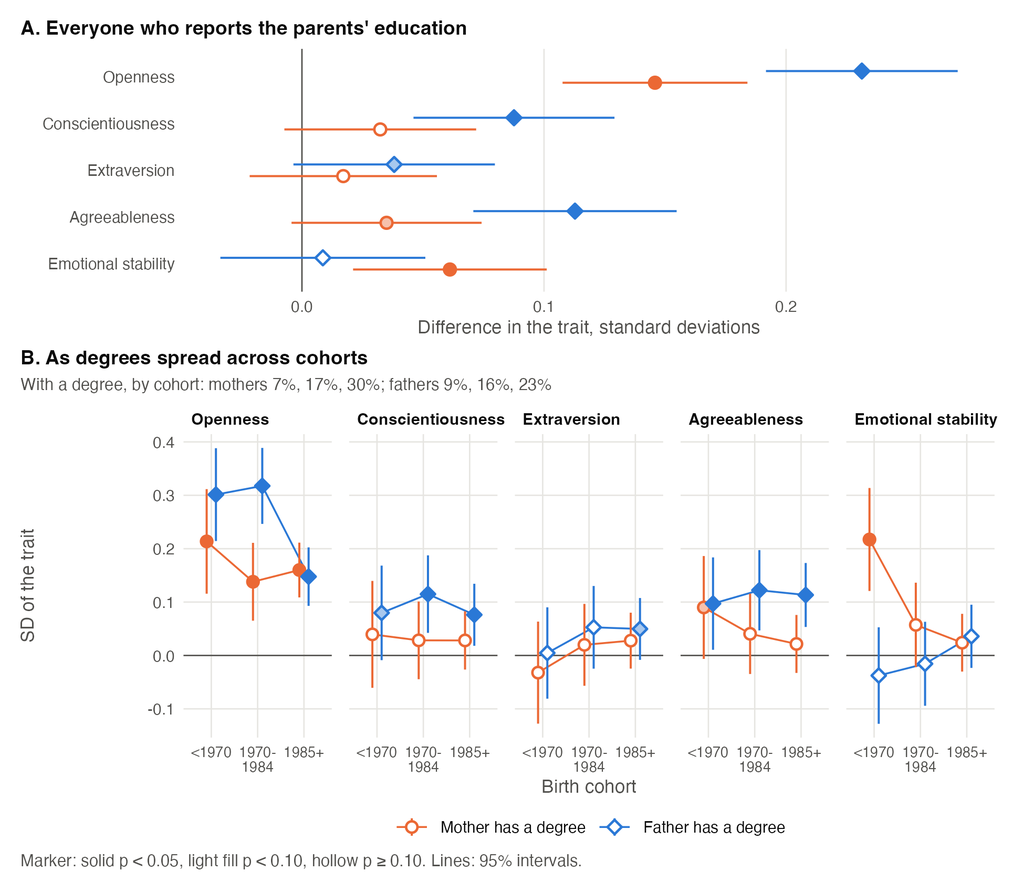

## Backup: what observed family characteristics account for

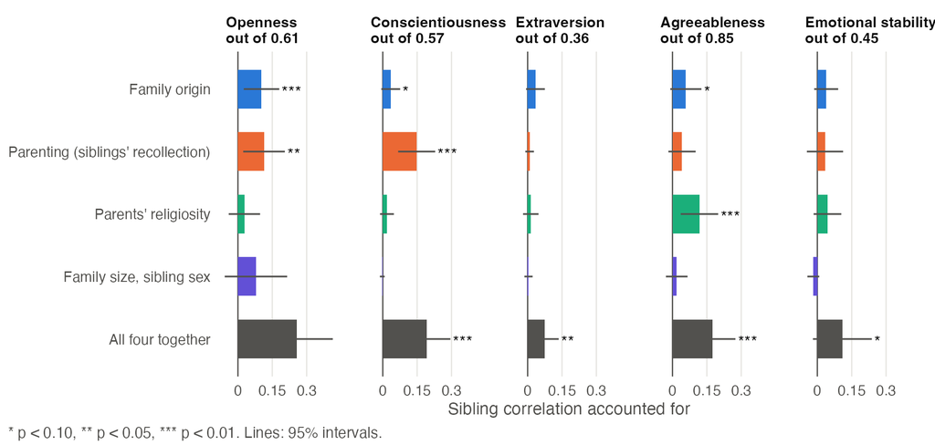

## Backup: opportunities outside the home

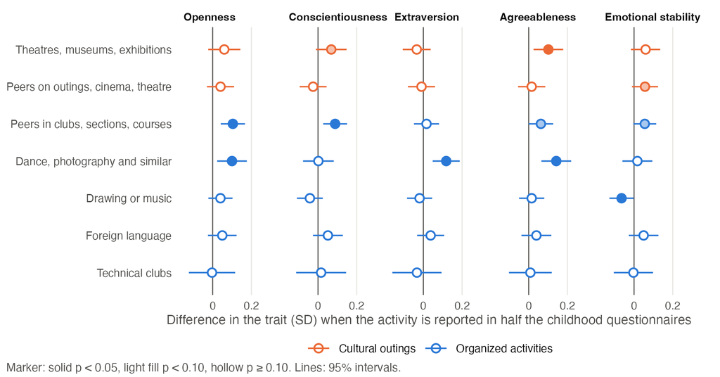

Child questionnaires from 2015: cultural outings, clubs, arts, and languages.

**Model**: OLS, one activity per regression, with income rank, parents’ degrees, and settlement held constant.

These are associations: interests and local access shape participation.

← Back to site